# A Representative Sample of Japanese Participants’ Attitudes Towards Government Tracking During the COVID-19 Pandemic

Prof Simon Dennis$^1$, Dr Paul Garrett$^1$, Mr Joshua White$^1$, A/Prof Daniel Little$^1$, A/Prof Amy Perfors$^1$, Prof Yoshihisa Kashima$^1$, Prof Stephan Lewandowsky$^2$, Prof Takashi Kusumi$^3$

$^1$Complex Human Data Hub, School of Psychological Sciences, The University of Melbourne.

$^2$School of Psychological Sciences, The University of Bristol.

$^3$Graduate School of Education, Kyoto University

28/07/2020

# Data Collection and Context

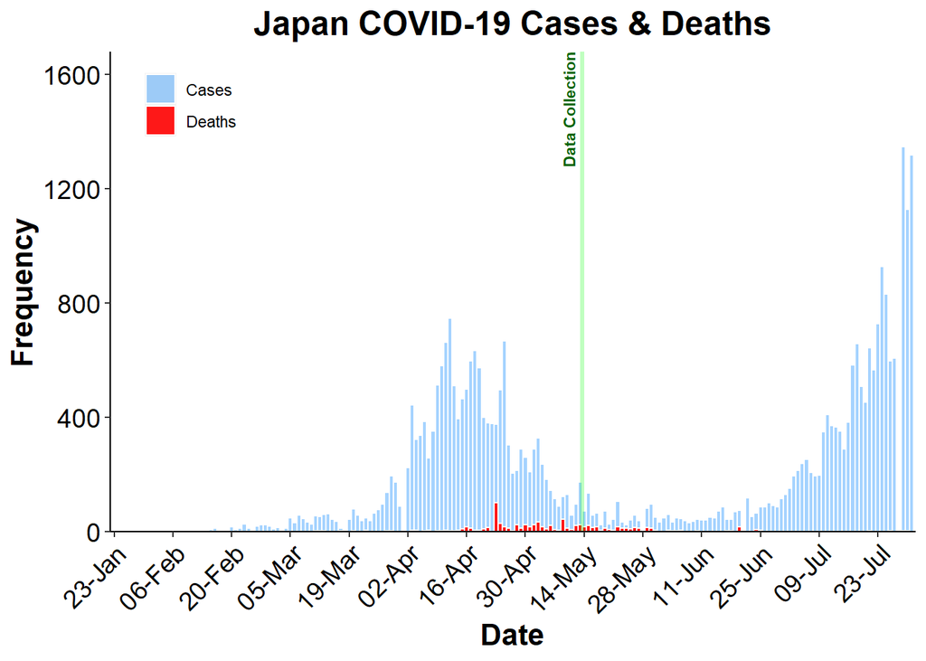

# Results

## Sample details

These results represent a snapshot from 1227 participants collected as part of the international project to understand public perceptions of privacy encroaching technologies to address COVID-19. This representative sample was gathered through the Japanese Market research firm ‘Cross Marketing’.

Notes on cleaning the data.

1. Of the initial 1227 participants collected,152 participants began and did not complete the survey.
2. Of the participants that did complete the survey, 393 did not pass the attention check.

After cleaning the data for the above participants, the final sample at analysis was 682 participants.

## Demographics

Our sample had a very flat age distribution and approximately equal numbers of men and women. Below, we also show the distribution of the regions of residence of our participants, their marital status, their education and whether they have children.

| Gender identification: Percentages | Gender identification: Percentages #Total |
| --- | --- |
| What is your gender? |  |
| Man | 49.3 |
| Woman | 50.7 |
| #Total cases | 682 |

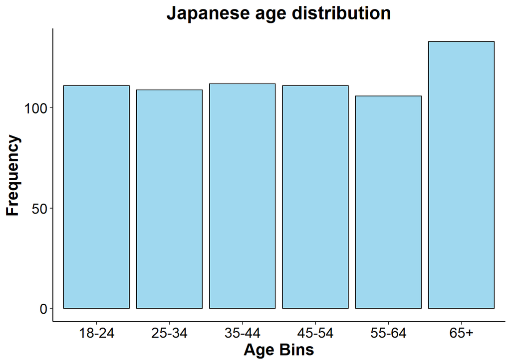

| Level of education: Percentages | Level of education: Percentages #Total |
| --- | --- |
| What is your highest level of education? |  |
| Not completed High School | 2.6 |
| Completed High School | 39.0 |
| Completed Junior College | 11.1 |
| Completed College | 40.8 |
| Completed Graduate School | 6.5 |
| #Total cases | 682 |

| Marital Status: Percentages | Marital Status: Percentages #Total |
| --- | --- |
| Are you married? |  |
| Unmarried | 38.4 |
| Married | 61.6 |
| #Total cases | 682 |

| Children status: Percentages | Children status: Percentages #Total |
| --- | --- |
| Do you have children? |  |
| Yes | 49.4 |
| no | 50.6 |
| #Total cases | 682 |

| Occupation: Percentages | Occupation: Percentages #Total |
| --- | --- |
| What is your occupation? |  |
| company | 30.2 |
| public servant | 3.5 |
| contract | 5.1 |
| self-employed | 3.1 |
| small business | 1.6 |
| primary industry | 0.3 |
| medical | 1.3 |
| professional | 0.7 |
| part time | 12.5 |
| homemaking | 16.0 |
| student | 9.4 |
| unemployed | 14.7 |
| other | 1.6 |
| #Total cases | 682 |

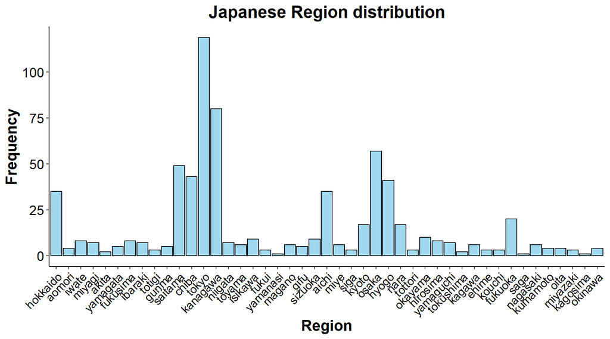

## Impacts of COVID

Our survey also asked participants about how they had experienced and been impacted by the COVID-19 pandemic.

Participants reported spending variable amounts of time in quarantine or lockdown, with the mean time being 41 days. Further, approximately 11% of participants reporting losing their job, either in part or whole. A majority of people got most of their news regarding the COVID-19 pandemic from television (65%), social media (15%) and newspapers (incl. online newspapers; 14%). Very few participants had themselves previously tested positing for COVID-19 (0.3%) or new somebody who had (1.3%).

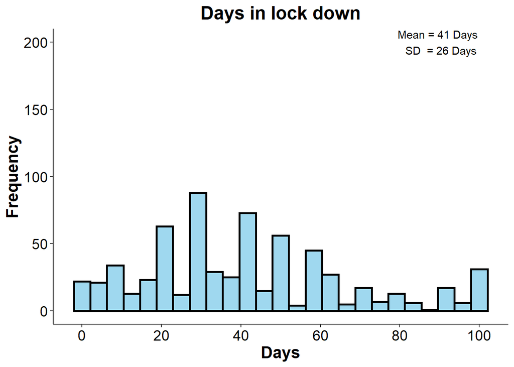

| Job lost due to COVID-19: Percentages | Job lost due to COVID-19: Percentages #Total |
| --- | --- |
| Lost job, in part or whole? |  |
| No | 89.1 |
| Yes | 10.9 |
| #Total cases | 682 |

| Information source: Percentagess | Information source: Percentagess #Total |
| --- | --- |
| Where do you get news about the COVID-19 pandemic? |  |
| Newspapers (incl. online) | 14.4 |
| Social Media | 14.8 |
| Friends and Family | 1.0 |
| Radio | 1.2 |
| Television | 65.1 |
| Other | 2.9 |
| Dont follow | 0.6 |
| #Total cases | 682 |

| Somebody I know tested positive for COVID-19: Percentages | Somebody I know tested positive for COVID-19: Percentages #Total |
| --- | --- |
| Tested Positive |  |
| No | 98.7 |
| Yes | 1.3 |
| #Total cases | 682 |

| I have tested positive for COVID-19: Percentages | I have tested positive for COVID-19: Percentages #Total |
| --- | --- |
| Tested Positive |  |
| No | 99.7 |
| Yes | 0.3 |
| #Total cases | 682 |

## Policy Complicance

Finally, we asked participants to estimate what percentage of the general population were complying with government social distancing policies. The graph below shows that these estimates were quite varied (*SD* = 21%), with the mean estimate being 55%.

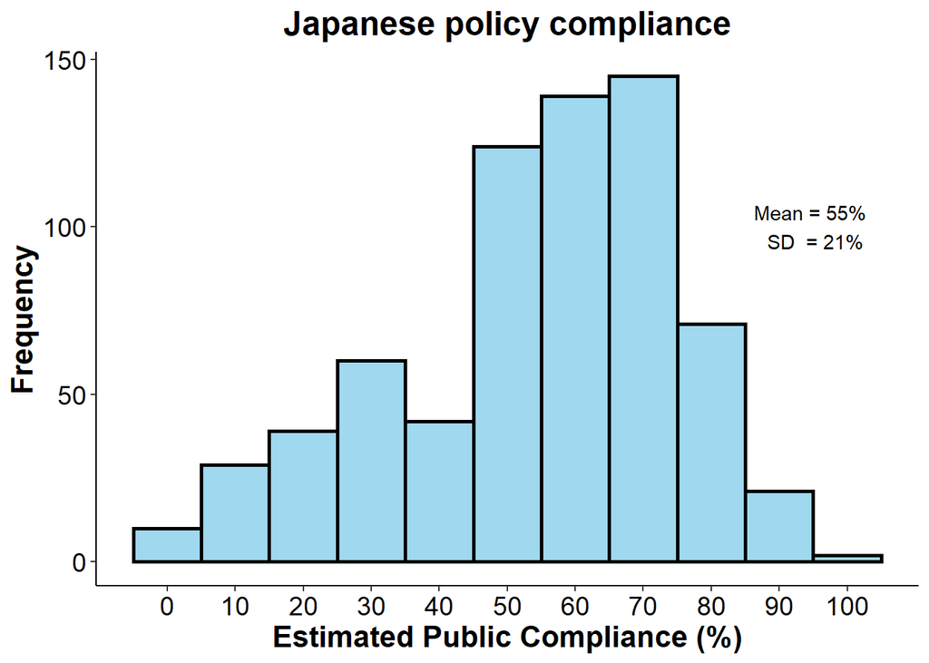

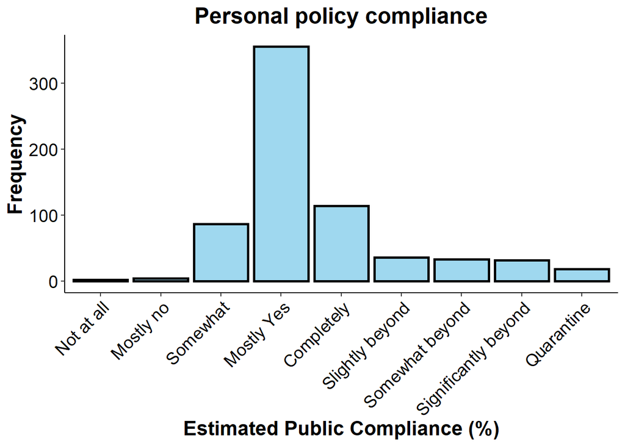

## Perceived Risk of COVID

Participants were asked four questions that asked them about their perceptions of the risk, and their worry about, the COVID pandemic.

1. How severe they believed the pandemic would be for the general population.
2. How severe they believed the pandemic would be for their personal health.
3. How concerned they are about contracting COVID-19.
4. How concerned are they about people they know contracting COVID-19.

The graph below shows participants responses to these questions.

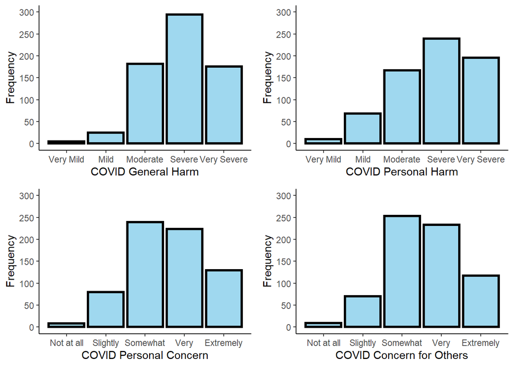

Finally, we asked participants to report their estimates on the number of fatalities across a range of countries. Responses were made on a sliding scale ranging from 0 - 100,000; results are reported in estimated deaths per 1000 (see violin plot below).

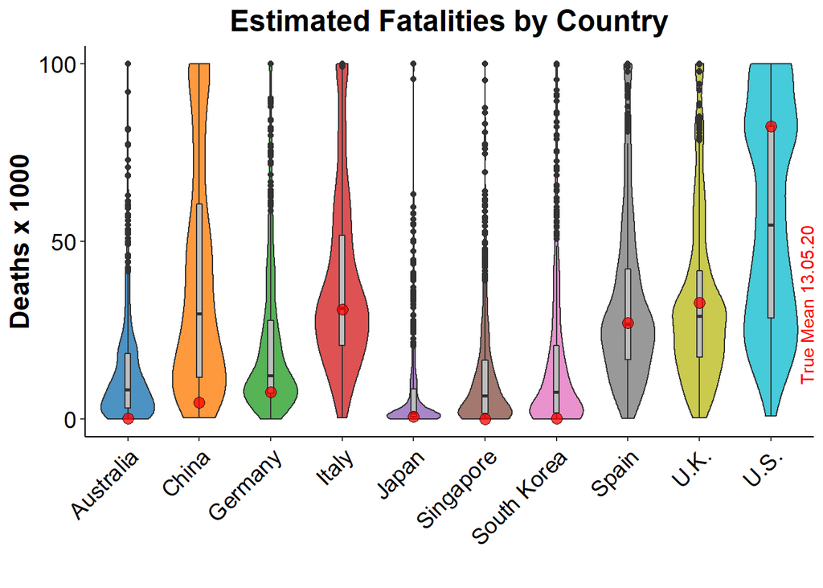

## Tracking App Scenarios

#### Decentralised Apple/Google Bluetooth App Scenario

The COVID-19 pandemic has rapidly become a worldwide threat. Containing the virus’ spread is essential to minimise the impact on the healthcare system, the economy, and save many lives. **Apple and Google have proposed adding a contact tracing capability to existing smartphones to help inform people if they have been exposed to others with COVID-19.** This would help reduce community spread of COVID-19 by allowing people to voluntarily self-isolate. When two people are near each other, their phones would connect via bluetooth. If a person is later identified as being infected, the people they have been in close proximity to are then notified **without the government knowing who they are. The use of this contact tracing capability would be completely voluntary. People who are notified would not be informed who had tested positive.**

## Intention to uptake tracking apps

Participants were then asked whether they would download and use the tracking app that they had just read about it. The were asked this twice: once immediately after reading about the app, and again after than had been asked questions about the risks and privacy implications of the app (see below). The graph below shows participants responses to these questions.

The data shows that approximately 45% - 50% of participants would download each of the apps.

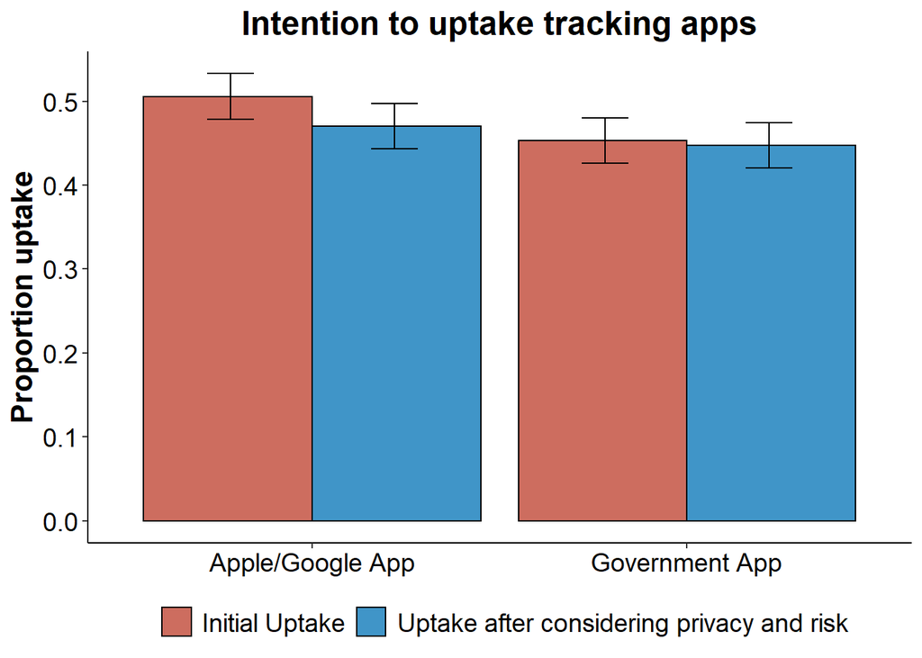

## Conditional intention to uptake of tracking apps

Participants who previously answered that they would not download the app (after answering questions about its risks and privacy implications), where then asked if they would do so if:

1. it was promised that the app and data taken from it would only be used for 6-months, after which it would all be permanently deleted (i.e., a ‘sunset’); and
2. for the Government app, the data from the app was not stored on a central server but rather kept on the individuals phone.

The graph below shows participants’ responses to these conditional questions compared to participants who indicated an unconditional intention to uptake the apps.

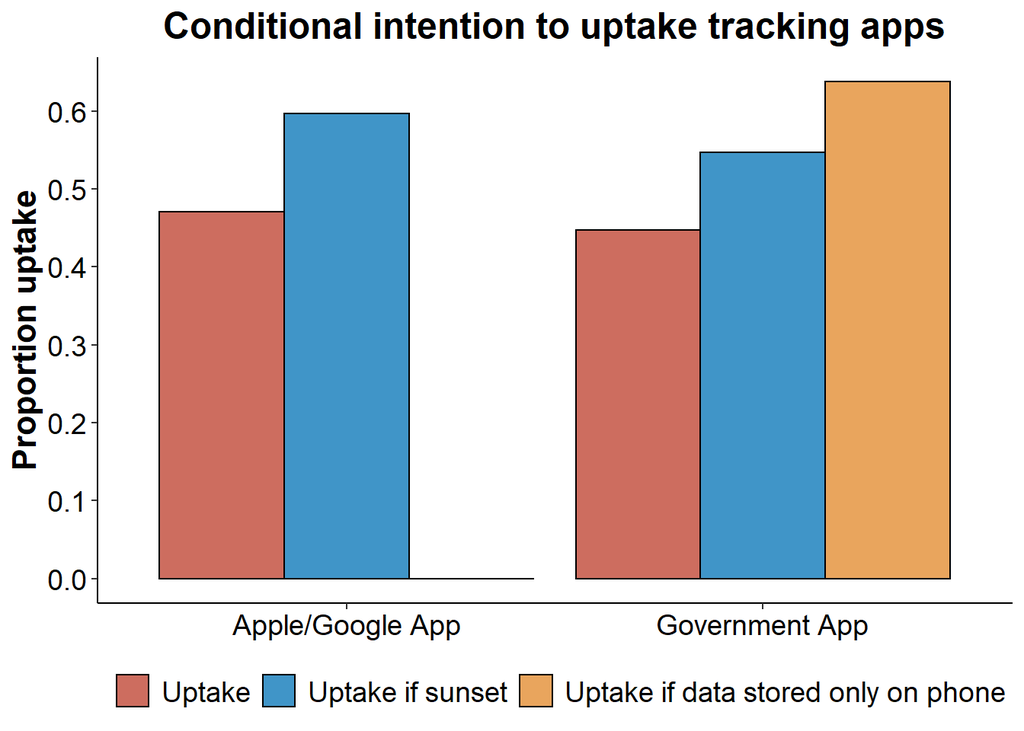

## Perceived Benefits of Tracking Apps

Participants were also asked for their confidence that in each scenario the tracking technology would:

1. Reduce their likelihood of contracting COVID-19
2. Allow them to resume their normal lives more rapidly
3. Reduce spread of COVID-19 in the community.

We ran (intercept only) Bayesian ordinal probit regressions on this data to find a measure of central tendency (and to respect the ordinal nature of the data). A higher ordinal regression intercept mean (plotted on the y axis with the line in the middle of the box) indicates higher average confidence. The upper and lower limits show the 95% highest posterior density interval of the intercept mean, giving the interval within which we are 95% confident the “true” intercept mean lies.

The below graph shows the data in its original form with a boxplot (A) and the results from the Bayesian ordinal probit regressions (B).

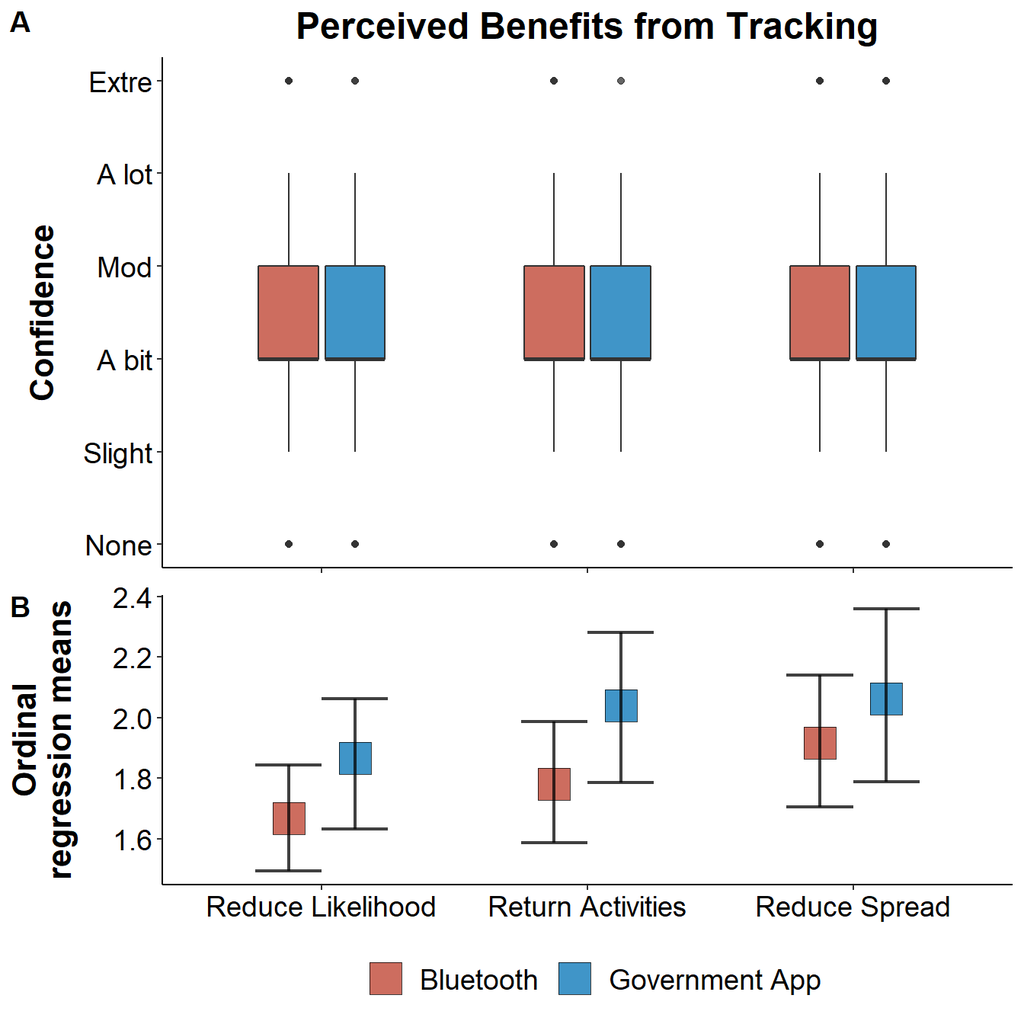

## Perceived risks and privacy implications of tracking technologies

Participants were also asked questions about the possible risks and privacy implications of each app. The next graph shows responses to the following items (abridged from survey):

1. How usable is the app for people like oneself?
2. How secure is the data that would be collected for the proposed project?
3. How difficult is it for people to decline participation in the proposed project?
4. To what extent do people have ongoing control of their data?
5. To what extent is the Government only collecting the data necessary?
6. How serious is the risk of harm that could arise from the proposed project?
7. How sensitive is the data being collected in the proposed project?
8. How much do you trust the Government to use the tracking data only to deal with the COVID-19 pandemic?
9. How much do you trust the Government to be able to ensure the privacy of each individual?

Again, we ran (intercept only) Bayesian ordinal probit regressions on this data to find a measure of central tendency (and to respect the ordinal nature of the data). A higher ordinal regression intercept mean (plotted on the y axis with the line in the middle of the box) indicates higher average confidence. The upper and lower limits show the 95% highest posterior density interval of the intercept mean, giving the interval within which we are 95% confident the “true” intercept mean lies.

The below graph shows the data in its original form with a boxplot (A) and the results from the Bayesian ordinal probit regressions (B).

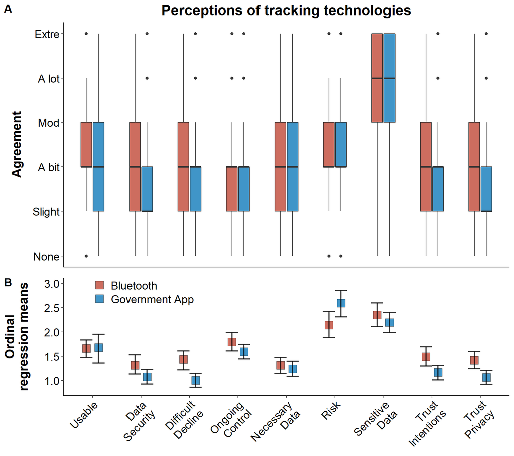

## Immunity Passports

### Introduction

Countries around the world are considering adopting ‘immunity passports’ — an electronic or physical identifier for those who have recovered from COVID-19 — as a response to COVID-19 to allow those that have shown immunity (although, the degree to which and for how long this immunity remains, still appears to be uncertain) to COVID-19 to return to normal life.

Although immunity passports present a means to rapidly re-open world economies, fears linger over the prospect of reinfection, more outbreaks, and the creation of a class-based economy. As those individuals with immunity passports return to work, go to gyms, gather at public events, and visit friends; those without will need to remain in lockdown to ensure healthcare systems do not become overrun. The introduction of immunity passports raises another concern: will individuals seek to self-infect with COVID-19 to return to normal activities sooner?

The concept of intentional self-infection is not new, you or your parent may have attended a pre-vaccination chicken pox party as a child; however, the potential risks in catching chicken pox and COVID-19 are literally life-and-death. But maybe this is a risk young, healthy & immunocompetent individuals are willing to take?

The notion of whether immunity passports are ‘fair’ and their perceived effectiveness by the public will dictate whether these temporary Government policies will be embraced. Here, we ask a representative sample of Japanese people about their attitudes to immunity passports as part of a Government response to COVID-19.

### Survey description

We began by presenting participants with this brief description of immunity passports, before asking questions about their attitudes towards their introduction in Japan

“An ‘immunity passport’ indicates that you have had a disease and that you have the antibodies for the virus causing that disease. Having the antibodies implies that you are now immune and therefore unable to spread the virus to other people. Thus, if an antibody test indicates that you have had the disease, you could be allocated an ‘immunity passport’ which would subsequently allow you to move around freely. Immunity passports have been proposed as a potential step towards lifting movement restrictions during the COVID-19 pandemic.”

Our questions regarding the public’s attitude towards immunity passports included:

1. Would you support a government proposal to introduce ‘immunity passports’ for novel coronavirus (COVID-19)?
2. How concerned are you about the idea of introducing an ‘immunity passport’ for novel coronavirus (COVID-19)?
3. How much would you like to be allocated an ‘immunity passport’ for novel coronavirus (COVID-19)?
4. To what extent do you believe an ‘immunity passport’ for novel coronavirus (COVID-19) could harm the social fabric of your country?
5. To what extent do you believe that it is fair for people with ‘immunity passports’ for novel coronavirus (COVID-19) to go back to work, while individuals without such an ‘immunity passport’ cannot?
6. To what extent would you consider purposefully infecting yourself with novel coronavirus (COVID-19) to get an ‘immunity passport’ for novel coronavirus (COVID-19)?
7. Would you support a government proposal to introduce ‘immunity passports’ for novel coronavirus (COVID-19)?

Note, we ask whether participants support the introduction of an immunity passport twice: once before and once after answer questions about the policy. This provides an initial ‘gut reaction’ response and a follow up response after being force to consider the implications of this measure. Responses were made on a 6 point Likert scale with anchors ‘1 - Not at all’ and ‘6 - Extremely’.

### Results

Results are shown in the graph below. In general, there was only ‘slight’ or ‘a bit of’ support for the introduction of immunity passports in Japan. Of note however, is that nearly all participants believe that introducing immunity passports will ‘not at all’ harm the social fabric of Japan.

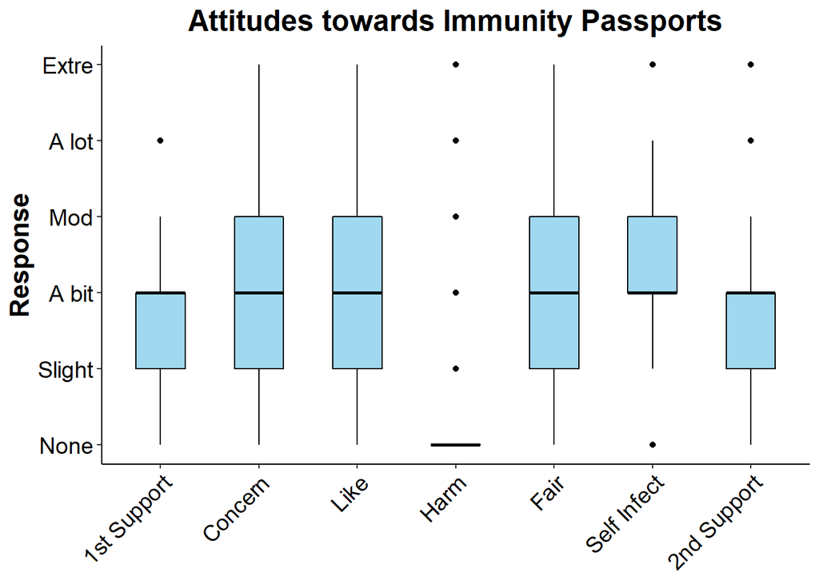

We next consider how these attitudes change across age ranges, and specifically, whether immunity passports appeal more to younger people who are less likely to be at risk from COVID-19 than older people.

Again, we ran (intercept only) Bayesian ordinal probit regressions on this data to find a measure of central tendency (and to respect the ordinal nature of the data). A higher ordinal regression intercept mean (plotted on the y axis with the line in the middle of the box) indicates higher average confidence. The upper and lower limits show the 95% highest posterior density interval of the intercept mean, giving the interval within which we are 95% confident the “true” intercept mean lies.

The below graph shows the data in its original form with a boxplot (A) and the results from the Bayesian ordinal probit regressions (B).

Within all age brackets, support for immunity passports decreased between the first assessment (occurring just after participants read the text description; 1st support), and the second assessment (occurring just after participants answered the immunity passport questions; 2nd support).

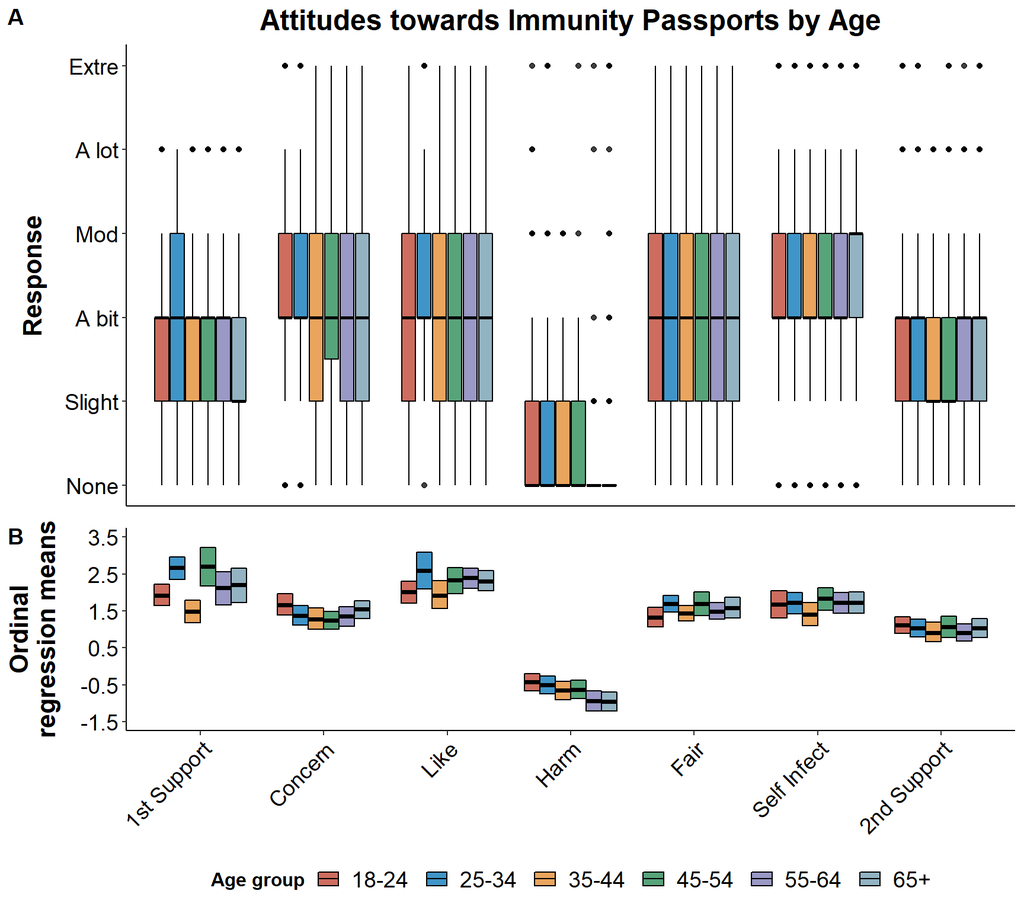